# Lab 09: Patch metrics

Ryan Reisinger

2026-11-19

# Introduction

Today we will look at a short example of using the `landscapemetrics` R package to calculate patch metrics from raster data. Remember, patch metrics are measures of the size, shape, and configuration of patches of habitat. This applies to the patch-mosaic and patch matrix models.

The package implements metrics from a computer programme called FRAGSTATS (https://www.fragstats.org/), which is widely used in landscape ecology. The package can calculate a wide variety of landscape metrics at the patch, class, and landscape levels.

The package’s website has some general background: https://r-spatialecology.github.io/landscapemetrics/articles/general_background.html

The paper describing the package can be found here: https://doi.org/10.1111/ecog.04617

```r
# Load packages
library(terra)
library(landscapemetrics)
library(dplyr)
```

# Exploring the built in landscape data

First, we’ll get some data. `landscapemetrics` has a few built-in datasets. Let’s use `podlasie_ccilc`, which is a land cover map of the Podlasie region of Poland. The data come from the **ESA Climate Change Initiative (CCI) Land Cover** project, which **provides global annual land cover maps at a 300-meter spatial resolution** https://maps.elie.ucl.ac.be/CCI/viewer/ Overall, there are 22 global land cover classes, of which we have 14 in the Podlasie data. You can see the legend for the classes here: https://maps.elie.ucl.ac.be/CCI/viewer/download/CCI-LC_Maps_Legend.pdf. These are:

| Value | Landscape class |
| --- | --- |
| 0 | No Data |
| 10 | Cropland, rainfed |
| 11 | Herbaceous cover |
| 12 | Tree or shrub cover |
| 20 | Cropland, irrigated or post-flooding |
| 30 | Mosaic cropland (>50%) / natural vegetation (tree, shrub, herbaceous cover) (<50%) |
| 40 | Mosaic natural vegetation (tree, shrub, herbaceous cover) (>50%) / cropland (<50%) |
| 50 | Tree cover, broadleaved, evergreen, closed to open (>15%) |
| 60 | Tree cover, broadleaved, deciduous, closed to open (>15%) |
| 61 | Tree cover, broadleaved, deciduous, closed (>40%) |
| 62 | Tree cover, broadleaved, deciduous, open (15–40%) |
| 70 | Tree cover, needleleaved, evergreen, closed to open (>15%) |
| 71 | Tree cover, needleleaved, evergreen, closed (>40%) |
| 72 | Tree cover, needleleaved, evergreen, open (15–40%) |
| 80 | Tree cover, needleleaved, deciduous, closed to open (>15%) |
| 81 | Tree cover, needleleaved, deciduous, closed (>40%) |
| 82 | Tree cover, needleleaved, deciduous, open (15–40%) |
| 90 | Tree cover, mixed leaf type (broadleaved and needleleaved) |
| 100 | Mosaic tree and shrub (>50%) / herbaceous cover (<50%) |
| 110 | Mosaic herbaceous cover (>50%) / tree and shrub (<50%) |
| 120 | Shrubland |
| 121 | Evergreen shrubland |
| 122 | Deciduous shrubland |
| 130 | Grassland |
| 140 | Lichens and mosses |
| 150 | Sparse vegetation (tree, shrub, herbaceous cover) (<15%) |
| 151 | Sparse tree (<15%) |
| 152 | Sparse shrub (<15%) |
| 153 | Sparse herbaceous cover (<15%) |
| 160 | Tree cover, flooded, fresh or brakish water |
| 170 | Tree cover, flooded, saline water |
| 180 | Shrub or herbaceous cover, flooded, fresh/saline/brakish water |
| 190 | Urban areas |
| 200 | Bare areas |
| 201 | Consolidated bare areas |
| 202 | Unconsolidated bare areas |
| 210 | Water bodies |
| 220 | Permanent snow and ice |

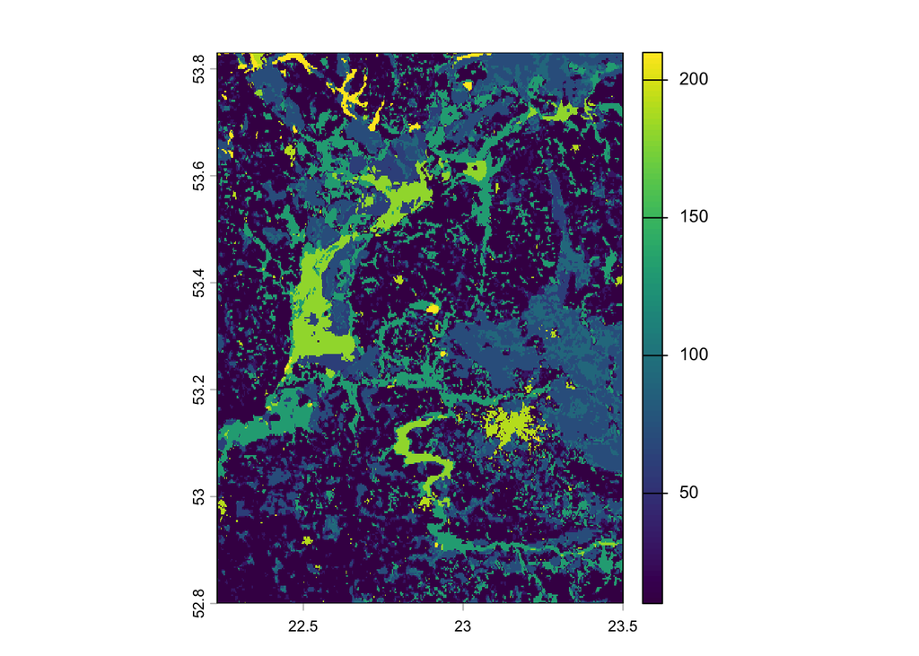

```r
# Get landscape data
# The terra::unwrap() function processes this kind of raster dataset
my_dat <- terra::unwrap(podlasie_ccilc)

# Plot to check
plot(my_dat)
```

Notice that terra’s generic plot function has given us colours on a continuous scale. It is treating the land cover classes, which have numbers, as continuous values. We could fix that by explicitly converting the raster to factors instead.

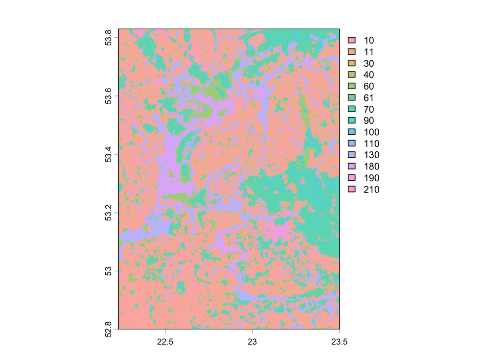

```r
# Convert raster to categorical/factor
my_dat <- as.factor(my_dat)

# Define discrete colours
# Here, I already know, from the next chunk below, that I need 14 colours
# "Set 3" is the name of a discrete colour
# palette: see https://blog.r-project.org/posts/hcl-colors/index.html)
cols <- hcl.colors(14, "Set 3")

# Plot again, with our defined colours
plot(my_dat, col = cols)
```

> **Challenge yourself**: In the raster and plot above we still have the generic class labels instead of the more meaningful names in the legend above. Ask a genAI tool to help you write code to give this raster object the real names of the land class categories from the table above.

It’s recommended to first use the `check_landscape()` function to make sure your raster is in the right format for analysis with the `landscapemetrics` package. (Note: we’ll keep using the `my_dat` object, with factors).

The requirements to calculate meaningful landscape metrics are:

- The distance units of your projection are meters, as the package converts units internally and returns results in either meters, square meters or hectares. For more information see the help file of each function (e.g., in R run `?check_landscape`).
- Your raster encodes landscape classes as integers (1, 2, 3, 4, …, n).
- Landscape metrics describe categorical landscapes, that means that your landscape needs to be classified (the package throws a warning if you have more than 30 classes to make sure you work with a classified landscape).

```r
check_landscape(my_dat)
```

```
## Warning: Caution: Coordinate reference system not metric - Units of results
## based on cellsizes and/or distances may be incorrect.
```

```
##   layer        crs   units   class n_classes OK
## 1     1 geographic degrees integer        14  ✖
```

From the table that this function returns we can see that:

✔ Our raster is categorical (it has integer values)

✖ It’s not in a projected coordinate system: the CRS is ‘geographic’ and the units are ‘degrees’ (it would be ‘meters’ if it was projected). Remember back to Lab 3. Let’s fix that. [Choosing a coordinate reference system is quite specific](https://learn.arcgis.com/en/projects/choose-the-right-projection/), but let’s choose a global, general projection for this excercise. We’ll use the Robinson projection, which is a global projection that roughly preserves area and shape. It’s not perfect, but it’s a good compromise for global data. I found the ‘proj4’ string for this projection on the https://epsg.io/53030 website. Note, we must set the `method` argument to equal `near` – nearest neighbour interpolation – otherwise when the reprojection occurs, the raster values will be changed from integer values to numeric values (remember from the line above, our raster must have integers, or whole numbers, representing the different classes).

```r
# Use the project function to reproject the data
# The argument 'y' is the projection 'proj4' string, which I got from the
# epsg website I mentioned above.
my_dat <- project(x = my_dat,
                  y = "+proj=robin
                  +lon_0=0
                  +x_0=0
                  +y_0=0
                  +R=6371000
                  +units=m
                  +no_defs
                  +type=crs",
                  method = "near")

# Alternatively, you could also use the ESRI code from
# the site https://spatialreference.org/ref/esri/53030/ like this:
# my_dat <- project(x = my_dat,
#                   y = "ESRI:53030",
#                   method = "near")
```

Now check our landscape again:

```r
check_landscape(my_dat) # All good!
```

```
##   layer       crs units   class n_classes OK
## 1     1 projected     m integer        14  ✔
```

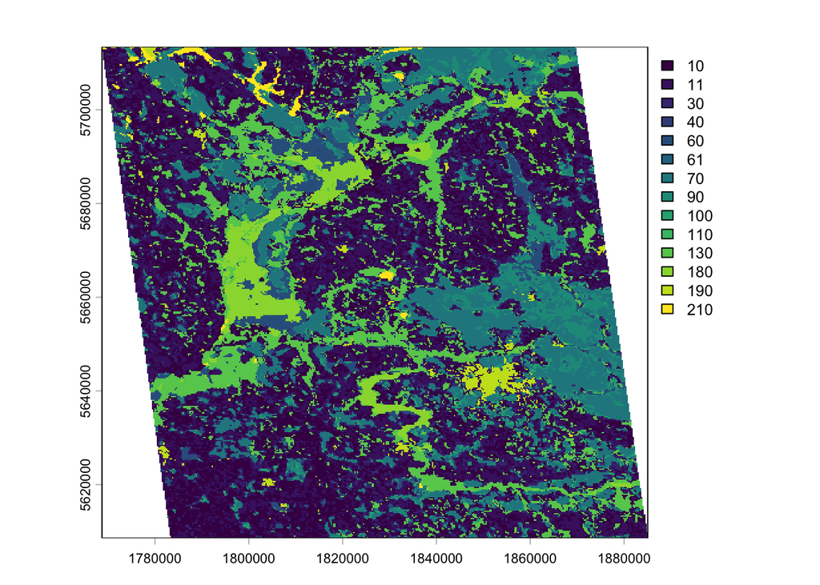

```r
plot(my_dat)
```

Notice that the axis values have changed (the map now has meter units instead of degree units, which was also shown in the check_landscape table) and the raster is a bit ‘skew’ because of the reprojection into a projected coordinate reference system.

We can also look at the patches using the `show_patches` function.

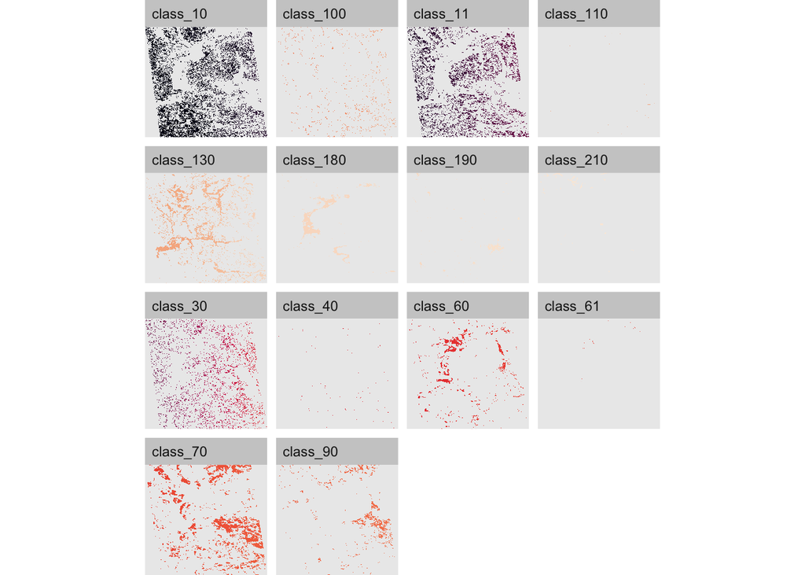

```r
# Show patches
# The class = "all' argument to this function specifies
# that we want to plot a so-called 'facet' for each class type
show_patches(my_dat, class = "all")
```

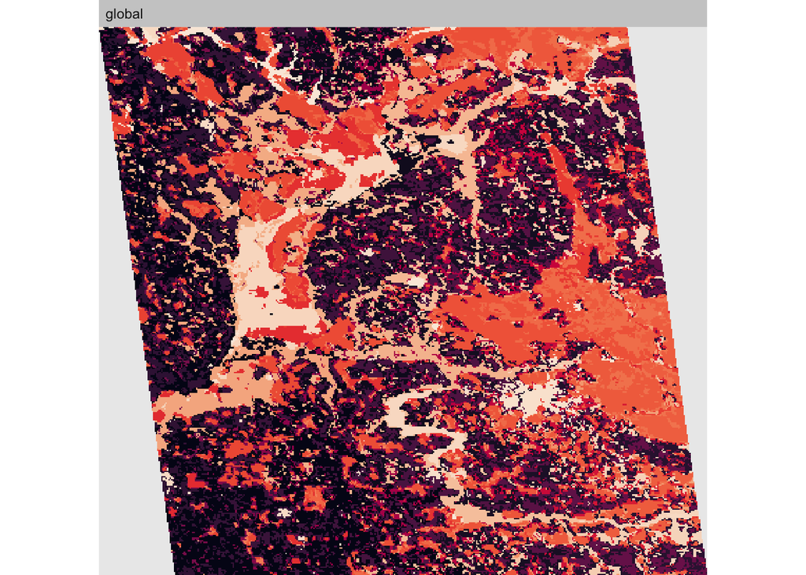

```r
# We could have done this if we wanted all the classes together
# on a single map
show_patches(my_dat, class = "global")
```

Now, we can calculate some metrics. From Lecture 4, recall that Table 2.1 and Table 2.2 in Pittman chapter 2 show metrics that we can calculate, or we can look in the paper [Wedding et al. 2011](https://doi.org/10.3354/meps09119).

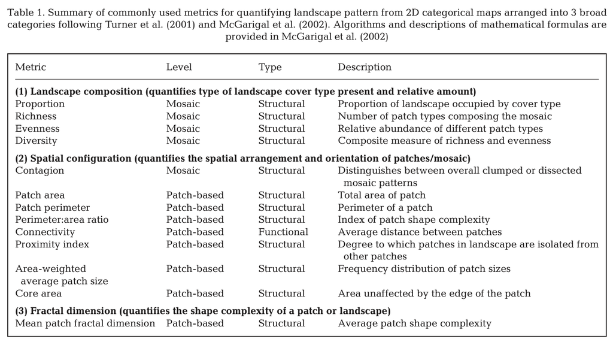

Table 1 from Wedding et al. (2011).

Remember that we can calculate patch-, class- and landscape-level metrics. All functions start with `lsm_` prefix (stands for landscapemetrics) and then `c`, `p`, or `l` for ‘class’, ‘patch’ or ’landscape level, respectively, followed by the specific function:

For example, patch-level area:

```r
# Patch-level
# This function calculates the area of each patch
patch_area <- lsm_p_area(my_dat)
patch_area
```

```
## # A tibble: 9,973 × 6
##    layer level class    id metric    value
##    <int> <chr> <int> <int> <chr>     <dbl>
##  1     1 patch    10     1 area    1807.
##  2     1 patch    10     2 area   17207.
##  3     1 patch    10     3 area       7.09
##  4     1 patch    10     4 area     128.
##  5     1 patch    10     5 area      28.3
##  6     1 patch    10     6 area     135.
##  7     1 patch    10     7 area      14.2
##  8     1 patch    10     8 area      21.3
##  9     1 patch    10     9 area      14.2
## 10     1 patch    10    10 area      35.4
## # ℹ 9,963 more rows
```

```r
# The patch-level function above will return an area value
# for _each_ patch in the map! (Thousands of values).
# So, let's do a bit more work to summarise the information returned
# We use dplyr to group the data table by class, then summarise the
# data, calculating the means, standard deviations, min and max values
# for each class
patch_area <- dplyr::group_by(patch_area, class)
patch_area <- dplyr::summarise(patch_area,
            mean_area = mean(value),
            sd_area = sd(value),
            min_area = min(value),
            max_area = max(value))
patch_area
```

```
## # A tibble: 14 × 5
##    class mean_area sd_area min_area max_area
##    <int>     <dbl>   <dbl>    <dbl>    <dbl>
##  1    10     201.  2073.       7.09  69942.
##  2    11     113.   311.       7.09   7130.
##  3    30      38.1   58.5      7.09   1417.
##  4    40      15.1    8.92     7.09     56.7
##  5    60      99.6  382.       7.09   5011.
##  6    61      18.3   10.3      7.09     49.6
##  7    70     243.  1167.       7.09  22891.
##  8    90      99.4  389.       7.09   6144.
##  9   100      27.1   26.8      7.09    234.
## 10   110      18.9   17.2      7.09    106.
## 11   130     135.   883.       7.09  16860.
## 12   180     392.  1990.       7.09  17661.
## 13   190      53.7  369.       7.09   5535.
## 14   210     154.   329.       7.09   1935.
```

```r
# You can use the class level function to more quickly return the mean area
# or the standard deviation
# (lsm_p_area = patch area versus lsm_c_area = class area)
mean_class_area <- lsm_c_area_mn(my_dat)
mean_class_area
```

```
## # A tibble: 14 × 6
##    layer level class    id metric  value
##    <int> <chr> <int> <int> <chr>   <dbl>
##  1     1 class    10    NA area_mn 201.
##  2     1 class    11    NA area_mn 113.
##  3     1 class    30    NA area_mn  38.1
##  4     1 class    40    NA area_mn  15.1
##  5     1 class    60    NA area_mn  99.6
##  6     1 class    61    NA area_mn  18.3
##  7     1 class    70    NA area_mn 243.
##  8     1 class    90    NA area_mn  99.4
##  9     1 class   100    NA area_mn  27.1
## 10     1 class   110    NA area_mn  18.9
## 11     1 class   130    NA area_mn 135.
## 12     1 class   180    NA area_mn 392.
## 13     1 class   190    NA area_mn  53.7
## 14     1 class   210    NA area_mn 154.
```

```r
sd_class_area <- lsm_c_area_sd(my_dat)
sd_class_area
```

```
## # A tibble: 14 × 6
##    layer level class    id metric    value
##    <int> <chr> <int> <int> <chr>     <dbl>
##  1     1 class    10    NA area_sd 2073.
##  2     1 class    11    NA area_sd  311.
##  3     1 class    30    NA area_sd   58.5
##  4     1 class    40    NA area_sd    8.92
##  5     1 class    60    NA area_sd  382.
##  6     1 class    61    NA area_sd   10.3
##  7     1 class    70    NA area_sd 1167.
##  8     1 class    90    NA area_sd  389.
##  9     1 class   100    NA area_sd   26.8
## 10     1 class   110    NA area_sd   17.2
## 11     1 class   130    NA area_sd  883.
## 12     1 class   180    NA area_sd 1990.
## 13     1 class   190    NA area_sd  369.
## 14     1 class   210    NA area_sd  329.
```

Here’s an example of calculate something called fractal dimension at the patch level. Because it is done at the patch level, there will be literally thousands of values (one row, or value, for each patch in the landscape!).

```r
patch_fractal <- lsm_p_frac(my_dat)
patch_fractal
```

```
## # A tibble: 9,973 × 6
##    layer level class    id metric value
##    <int> <chr> <int> <int> <chr>  <dbl>
##  1     1 patch    10     1 frac    1.21
##  2     1 patch    10     2 frac    1.28
##  3     1 patch    10     3 frac    1
##  4     1 patch    10     4 frac    1.14
##  5     1 patch    10     5 frac    1.04
##  6     1 patch    10     6 frac    1.08
##  7     1 patch    10     7 frac    1.01
##  8     1 patch    10     8 frac    1.02
##  9     1 patch    10     9 frac    1.01
## 10     1 patch    10    10 frac    1.07
## # ℹ 9,963 more rows
```

Class-level metrics can be calculated similarly. For example:

```r
# Total area of each class
total_class_area <- lsm_c_ca(my_dat)
total_class_area
```

```
## # A tibble: 14 × 6
##    layer level class    id metric   value
##    <int> <chr> <int> <int> <chr>    <dbl>
##  1     1 class    10    NA ca     302502.
##  2     1 class    11    NA ca     191377.
##  3     1 class    30    NA ca     102315.
##  4     1 class    40    NA ca       1949.
##  5     1 class    60    NA ca      44910.
##  6     1 class    61    NA ca        475.
##  7     1 class    70    NA ca     148586.
##  8     1 class    90    NA ca      40049.
##  9     1 class   100    NA ca      26279.
## 10     1 class   110    NA ca        624.
## 11     1 class   130    NA ca     145354.
## 12     1 class   180    NA ca      39616.
## 13     1 class   190    NA ca      12360.
## 14     1 class   210    NA ca       7370.
```

```r
# Percent of landscape of each class
percent_class_area <- lsm_c_pland(my_dat)
percent_class_area
```

```
## # A tibble: 14 × 6
##    layer level class    id metric   value
##    <int> <chr> <int> <int> <chr>    <dbl>
##  1     1 class    10    NA pland  28.4
##  2     1 class    11    NA pland  18.0
##  3     1 class    30    NA pland   9.62
##  4     1 class    40    NA pland   0.183
##  5     1 class    60    NA pland   4.22
##  6     1 class    61    NA pland   0.0446
##  7     1 class    70    NA pland  14.0
##  8     1 class    90    NA pland   3.76
##  9     1 class   100    NA pland   2.47
## 10     1 class   110    NA pland   0.0586
## 11     1 class   130    NA pland  13.7
## 12     1 class   180    NA pland   3.72
## 13     1 class   190    NA pland   1.16
## 14     1 class   210    NA pland   0.693
```

Landscape-level metrics are calculated without grouping by class or patch. For example, landscape-level ‘contagion’ (https://www.fragstats.org/index.php/fragstats-metrics/patch-based-metrics/aggregation-metrics/l1-contagion-index):

```r
# Landscape-level
landscape_contagion <- lsm_l_contag(my_dat)
landscape_contagion
```

```
## # A tibble: 1 × 6
##   layer level     class    id metric value
##   <int> <chr>     <int> <int> <chr>  <dbl>
## 1     1 landscape    NA    NA contag  39.7
```

```r
# Note that landscape-level metrics return a single value
```

You can calculate many different metrics. See the package documentation for a full list: https://r-spatialecology.github.io/landscapemetrics/reference/index.html

You’ll need to look at the options and think about what makes sense to calculate (think about what the ecological *meaning* of a metric might be. Tables like the one from Wedding et al. (2011) above are a good place to start.

More information on each of the metrics is on the FRAGSTATS page at https://www.fragstats.org/index.php/documentation (navigate to the metrics using the navigation on the left hand side of the web page).

Here are some examples of how we could interpret some of these metrics:

**Interpretation table** (typical directions; they depend on the process)

| Metric | Type | High value means | Loss alone | Fragmentation alone |
| --- | --- | --- | --- | --- |
| `pland`, `ca` | composition | more of the landscape is this class | ↓ | no change |
| `np` | configuration | more separate patches | same or ↓ | ↑ |
| `area_mn` | configuration | larger patches on average | ↓ | ↓ |
| `lpi` | configuration | one patch dominates | ↓ | ↓ |
| `ed` | configuration | more edge per area | usually ↓ | ↑ |
| `enn_mn` | isolation | patches are further apart | ↑ | ↑ |
| `contag` (landscape) | aggregation | clumped, large contiguous patches | – | ↓ |

# An example with seascape data

Let’s try an example of looking at some metrics for a seascape instead of a landscape.

We can use data from something called the EUSeaMap 2025 Broad-Scale Predictive Habitat Map for Europe. More information is given here:  
https://emodnet.ec.europa.eu/geonetwork/srv/eng/catalog.search#/metadata/cec07b5e-3a9c-4492-b115-126a17c08697

You can use their viewer to explore and download the data (https://emodnet.ec.europa.eu/geoviewer/#).

Because the dataset is big, and a little tricky to work with, I have done some preprocessing for you. I did the following

- I went to the data catalogue: https://emodnet.ec.europa.eu/geonetwork/srv/eng/catalog.search
- I then searched for “EUSeaMap 2025 Broad-Scale Predictive Habitat Map for Europe”
- Under filters, I selected ‘Type of Resource’ = ‘Dataset’, which returned 5 datasets
- I chose the first dataset and clicked on download icon, which let me download a zip file of the data
- The direct link is: https://files.emodnet-seabedhabitats.eu/data/EUSeaMap_2025.zip (if you copy and paste this name into your internet browser, or follow the link, it will prompt a download; watch out, though–the file is over 2GB!). You can read more about the data here: https://gis.ices.dk/geonetwork/srv/eng/catalog.search#/metadata/cec07b5e-3a9c-4492-b115-126a17c08697
- I unzipped the file, and from there found the vector data called “EUSeaMap_2025.gpkg” (.gpkg is a type of vector data format).
- I saved that file in my working directory, in a subfolder called ‘data’.
- I then ran the following in R (you don’t have the files for this to work, unless you have downloaded and unzipped them yourself, so don’t try to run this chunk):

```r
# We'll need the sf package
# Notice that I'm using 'require()' instead of 'library()'
# this only loads the package if it hasn't been loaded already
require(sf)
```

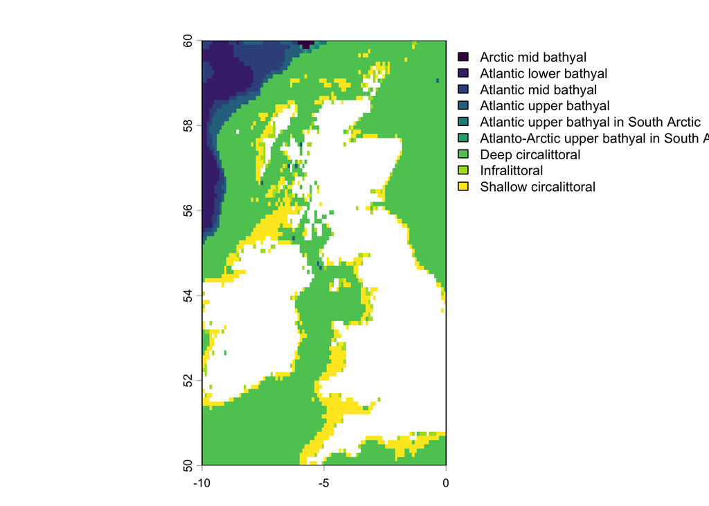

```r
# Read in the vector data using the terra::vect functiion
seamap_vector = vect("data/EUSeaMap_2025/EUSeaMap_2025.gpkg")

# Create a raster template so we can crop and rasterize the vector data
# First define the geographic extent we want, giving
# four values in the order xmin, xmax, ymin, ymax)
seamap_crop <- ext(-10, +0, +50, +60)

# Then create an empty raster that we will use as a template to
# 'rasterize' the vector (convert it from vector to raster)
y = rast(seamap_crop, res = c(0.1, 0.1), crs = "EPSG:4326")

# Rasterize the vecor data, using the "Biozone" field in the vector
# data to assign values to the raster cells
seamap_raster = rasterize(seamap_vector, y, field="Biozone")

# Plot to check
plot(seamap_raster)
```

```r
# Save the raster we made as a geotiff file for later use
# You will read this file back in in the next step
writeRaster(seamap_raster, "data/seamap.tif",
            filetype = "GTiff",
            overwrite = TRUE)
```

Let’s go from there…

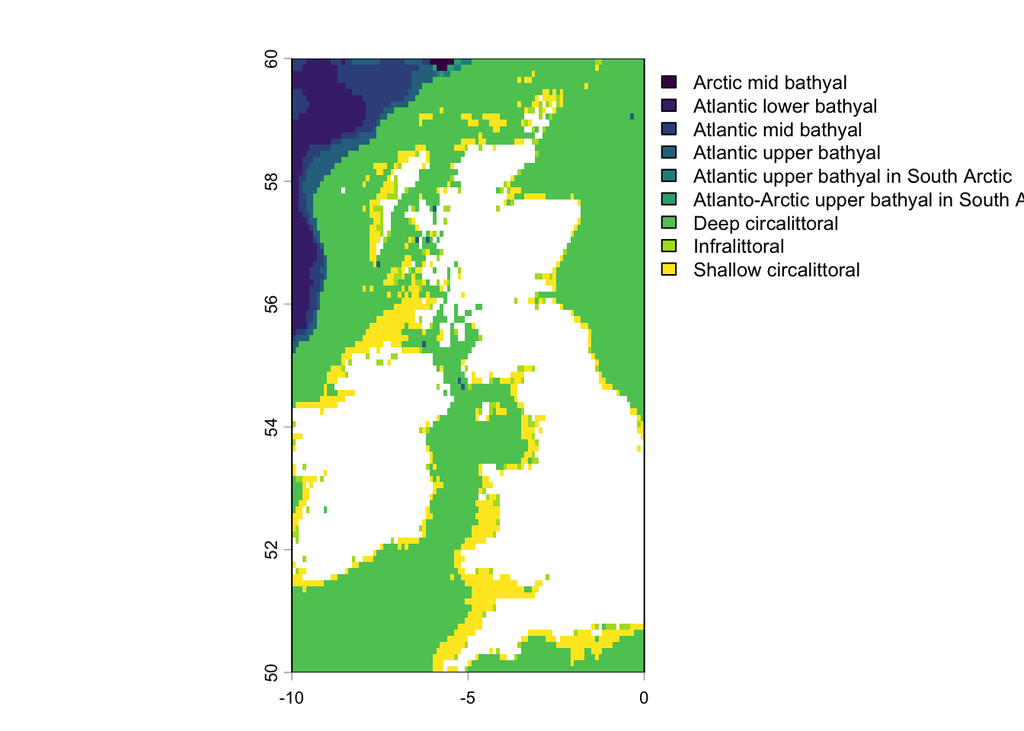

```r
# Load the seascape data
# You will need to download the data from here:
# https://github.com/ryanreisinger/SOES3056/tree/main/Lab%2009/data

# IMPORTANT!! There are _two_ files you should download from the
# folder:
# 1. seamap.tif
# 2. seamap.tif.aux.xml

# Save _both_ into your 'data' folder and then read the tif in like so
seascape <- rast("data/seamap.tif")
# (R will understand that the second file will be in the same place)

# Plot to check that it's what you expected
plot(seascape)
```

```r
# Check the landscape
check_landscape(seascape)
```

```
##   layer        crs   units   class n_classes OK
## 1     1 geographic degrees integer         9  ✖
```

```r
# Our raster is categorical (it has integers for the classes), but it is not projected (the units are degrees).
# Let's reproject it to the Robinson
# projection (https://spatialreference.org/ref/esri/53030/)
# like we did before.
seascape <- project(x = seascape,
                   y = "ESRI:53030",
                   method = "near")

# Check again
check_landscape(seascape)
```

[output not shown]

```r
# Now we can calculate some metrics
# Let's look at class-level metrics of total area and percent of landscape
total_class_area_seascape <- lsm_c_ca(seascape)
total_class_area_seascape
```

```
## # A tibble: 9 × 6
##   layer level class    id metric     value
##   <int> <chr> <int> <int> <chr>      <dbl>
## 1     1 class     2    NA ca        71283.
## 2     1 class     6    NA ca      2550364.
## 3     1 class     8    NA ca      1853370.
## 4     1 class    10    NA ca      1195978.
## 5     1 class    12    NA ca        55443.
## 6     1 class    14    NA ca        39602.
## 7     1 class    17    NA ca     33233933.
## 8     1 class    18    NA ca      1243500.
## 9     1 class    20    NA ca      6407591.
```

```r
percent_class_area_seascape <- lsm_c_pland(seascape)
percent_class_area_seascape
```

```
## # A tibble: 9 × 6
##   layer level class    id metric   value
##   <int> <chr> <int> <int> <chr>    <dbl>
## 1     1 class     2    NA pland   0.153
## 2     1 class     6    NA pland   5.47
## 3     1 class     8    NA pland   3.97
## 4     1 class    10    NA pland   2.56
## 5     1 class    12    NA pland   0.119
## 6     1 class    14    NA pland   0.0849
## 7     1 class    17    NA pland  71.2
## 8     1 class    18    NA pland   2.67
## 9     1 class    20    NA pland  13.7
```

```r
# Try calculating some metrics for yourself...
```

# Summary

- **Data preparation comes first.** Landscape metrics need a categorical raster of integer classes in a *projected* coordinate system with metric units. Cell size and distances feed into area and edge metrics, so the projection and resolution you choose affect your results. Use `check_landscape()` before you calculate anything.
- **Metrics work at three levels.** Patch-level metrics (`lsm_p_*`) return one value per patch, class-level metrics (`lsm_c_*`) one per class, and landscape-level metrics (`lsm_l_*`) one for the whole map. Patch-level output is long, so summarise it, for example by mean, standard deviation and range per class.
- **Composition is not configuration.** Composition metrics (`pland`, `ca`) say how much of each class there is, and quantify *loss*. Configuration metrics (`np`, `area_mn`, `lpi`, `ed`, `contag`) say how it is arranged, and quantify *fragmentation*. Two maps with the same cover can have very different configurations, which is why you need both kinds.
- **Interpret metrics in context.** A value only means something relative to the process and to other maps (another place, another time, another scale). Use the interpretation table above, and think about the ecological meaning of each metric before you use it. Many metrics are strongly correlated with each other and with total habitat amount.
- **Patch sizes are usually skewed.** A few very large patches and many tiny ones are typical, so the mean can be misleading. Look at the spread (the standard deviation and the range), not just the mean.
- **Your choices shape the answer.** Resolution, the number of classes, and how the data were classified or rasterised all change metric values, so compare metrics only between maps made the same way. The seascape example shows this: we rasterised the vector biozone map at 0.1° resolution, and a different resolution or a different set of classes would give different numbers.
- **Link to the lectures.** This is the quantitative toolkit behind the patch-mosaic model and the idea of habitat loss versus fragmentation. Next, applying the same metrics to maps from different times shows how patches change.

# Homework: Try for yourself

Work through the tasks below. Tasks 1 and 2 should take about 15 minutes each. Task 3 is optional.

## Task 1: Describe the Podlasie landscape

1. Calculate at least **two composition** metrics and **two configuration** metrics at the class level for `my_dat`. Choose from `pland`, `ca`, `np`, `area_mn`, `lpi` and `ed`. Use `calculate_lsm()` to get several metrics in one call:

```r
metrics <- calculate_lsm(my_dat, level = "class",
                         metric = c("pland", "ca", "np", "area_mn", "lpi", "ed"))

# Reshape so each metric is a column
metrics_wide <- tidyr::pivot_wider(metrics, id_cols = class,
                                   names_from = metric, values_from = value)
metrics_wide
```

[output not shown]

2. Pick **one class** (use the legend table above to name it). In two or three sentences, describe whether it is abundant or rare, and whether it forms a few large patches or many small ones. Use the numbers to support your answer.

> **Check your understanding.** Which metric(s) tell you about *loss*, and which about *fragmentation*? Could two classes have the same `pland` but very different `np`? What would that mean?

## Task 2: Compare the landscape with the seascape

1. Calculate the same metrics for `seascape`.
2. Compare the two maps:
   - Which class in each map has the largest `lpi` (largest patch index)?
   - Does a higher `np` go with a lower `area_mn` in both maps?
   - Which map looks more fragmented overall? Check with `lsm_l_contag()`.
3. Write two or three sentences on whether the differences you see are likely to reflect ecology, or the way the data were made (resolution, classification, how the vector data were rasterised).

> **Check your understanding.** The seascape raster was made by rasterising a vector map at a resolution of 0.1°. How might a different resolution change `np` and `area_mn`?

## Task 3 (stretch): Does scale change your answer?

Aggregate the Podlasie raster to coarser grain sizes and recalculate a few landscape-level metrics:

```r
scale_test <- dplyr::bind_rows(lapply(c(1, 2, 4, 8), function(f) {
  r <- if (f == 1) my_dat else aggregate(my_dat, fact = f, fun = "modal")
  dplyr::mutate(calculate_lsm(r, level = "landscape",
                              metric = c("np", "area_mn", "contag")),
                factor = f)
}))
scale_test
```

[output not shown]

1. How do `np`, `area_mn` and `contag` change as the cells get coarser?
2. The landscape itself did not change. Why do the numbers change?

> **Check your understanding.** Why is it a problem to compare metrics from two maps that have different resolutions?